# CTaylorMSDS6306402Unit6CaseStudy GDP Vs EDSTAT

Celia Taylor

June 21, 2016

#### Case Study of Country GDP and Country Federal Statistics

##### This study is to answer 5 main questions.

##### Question 1 Match the data based on the country shortcode. How many of the IDs match between the data from GDP data file and EDSTAT data file?

##### Question 2 Sort the data frame in ascending order by GDP rank (so United States is last). What is the 13th country in the resulting data frame?

##### Question 3 What are the average GDP rankings for the “High income: OECD” and “High income: nonOECD” groups?

##### Question 4 Plot the GDP for all of the countries. Use ggplot2 to color your plot by Income Group.

##### Question 5 Cut the GDP ranking into 5 separate quantile groups. Make a table versus Income.Group. How many countries are Lower middle income but among the 38 nations with highest GDP?

##### To answer these questions and learn something about the economics of the countries of the world, the specific data from two different files will be brought together, analyzed, and appropriately handled to show the data.

##### All steps are shown for the integrity of the case study.

##### Download data files, specifically Federal Gross Domestic Product information (GDP) and Federal Statistics by Country (EDSTAT) information.

```r
install.packages("downloader", repos="http://cran.rstudio.com/")
```

```r
library(downloader)
download("https://d396qusza40orc.cloudfront.net/getdata%2Fdata%2FGDP.csv", destfile="GDP.csv")
download("https://d396qusza40orc.cloudfront.net/getdata%2Fdata%2FEDSTATS_Country.csv", destfile="edstat.csv")
#list.files()
```

```r
##### Load packages and functions

#install.packages(c( "plyr",  "brew",  "countrycode",  "devtools", "dplyr", "ggplot2", "googleVis", "knitr", "MCMCpack", "repmis", "RCurl", "rmarkdown", "markdown", "texreg", "tidyr", "WDI", "xtable", "Zelig", "car", "Rtools"), repos="http://cran.rstudio.com/")

#library(plyr)
#library(brew)
#library(countrycode)
#library(devtools)
#library(ggplot2)
#library(googleVis)
#library(knitr)
#library(MCMCpack)
#library(repmis)
#library(RCurl)
#library(rmarkdown)
#library(texreg)
#library(tidyr)
#library(WDI)
#library(xtable)
#library(Zelig)
#library(markdown)
#library(car)
#library(dplyr)
#sessionInfo()
#End of install packages
library(ggplot2)
library(dplyr)
```

##### Read in edstat.csv file with additional options.

```r
#####
##### Read in edstat.csv file with additional options.  Get rid of any blank lines.
ed <- read.csv("edstat.csv", header = TRUE, sep = ",", stringsAsFactors = FALSE, nrows = 236, blank.lines.skip = TRUE)
str(ed)
```

```
## 'data.frame':    234 obs. of  31 variables:
##  $ CountryCode                                      : chr  "ABW" "ADO" "AFG" "AGO" ...
##  $ Long.Name                                        : chr  "Aruba" "Principality of Andorra" "Islamic State of Afghanistan" "People's Republic of Angola" ...
##  $ Income.Group                                     : chr  "High income: nonOECD" "High income: nonOECD" "Low income" "Lower middle income" ...
##  $ Region                                           : chr  "Latin America & Caribbean" "Europe & Central Asia" "South Asia" "Sub-Saharan Africa" ...
##  $ Lending.category                                 : chr  "" "" "IDA" "IDA" ...
##  $ Other.groups                                     : chr  "" "" "HIPC" "" ...
##  $ Currency.Unit                                    : chr  "Aruban florin" "Euro" "Afghan afghani" "Angolan kwanza" ...
##  $ Latest.population.census                         : chr  "2000" "Register based" "1979" "1970" ...
##  $ Latest.household.survey                          : chr  "" "" "MICS, 2003" "MICS, 2001, MIS, 2006/07" ...
##  $ Special.Notes                                    : chr  "" "" "Fiscal year end: March 20; reporting period for national accounts data: FY." "" ...
##  $ National.accounts.base.year                      : chr  "1995" "" "2002/2003" "1997" ...
##  $ National.accounts.reference.year                 : int  NA NA NA NA 1996 NA NA 1996 NA NA ...
##  $ System.of.National.Accounts                      : int  NA NA NA NA 1993 NA 1993 1993 NA NA ...
##  $ SNA.price.valuation                              : chr  "" "" "VAB" "VAP" ...
```

[output cut: 17 more lines]

```r
#Make a backup copy to manipulate
edraw <- ed
#Make sure structure is okay
str(edraw)
```

```
## 'data.frame':    234 obs. of  31 variables:
##  $ CountryCode                                      : chr  "ABW" "ADO" "AFG" "AGO" ...
##  $ Long.Name                                        : chr  "Aruba" "Principality of Andorra" "Islamic State of Afghanistan" "People's Republic of Angola" ...
##  $ Income.Group                                     : chr  "High income: nonOECD" "High income: nonOECD" "Low income" "Lower middle income" ...
##  $ Region                                           : chr  "Latin America & Caribbean" "Europe & Central Asia" "South Asia" "Sub-Saharan Africa" ...
##  $ Lending.category                                 : chr  "" "" "IDA" "IDA" ...
##  $ Other.groups                                     : chr  "" "" "HIPC" "" ...
##  $ Currency.Unit                                    : chr  "Aruban florin" "Euro" "Afghan afghani" "Angolan kwanza" ...
##  $ Latest.population.census                         : chr  "2000" "Register based" "1979" "1970" ...
##  $ Latest.household.survey                          : chr  "" "" "MICS, 2003" "MICS, 2001, MIS, 2006/07" ...
##  $ Special.Notes                                    : chr  "" "" "Fiscal year end: March 20; reporting period for national accounts data: FY." "" ...
##  $ National.accounts.base.year                      : chr  "1995" "" "2002/2003" "1997" ...
##  $ National.accounts.reference.year                 : int  NA NA NA NA 1996 NA NA 1996 NA NA ...
##  $ System.of.National.Accounts                      : int  NA NA NA NA 1993 NA 1993 1993 NA NA ...
##  $ SNA.price.valuation                              : chr  "" "" "VAB" "VAP" ...
```

[output cut: 17 more lines]

```r
head(edraw,2)
```

```
##   CountryCode               Long.Name         Income.Group
## 1         ABW                   Aruba High income: nonOECD
## 2         ADO Principality of Andorra High income: nonOECD
##                      Region Lending.category Other.groups Currency.Unit
## 1 Latin America & Caribbean                               Aruban florin
## 2     Europe & Central Asia                                        Euro
##   Latest.population.census Latest.household.survey Special.Notes
## 1                     2000
## 2           Register based
##   National.accounts.base.year National.accounts.reference.year
## 1                        1995                               NA
## 2                                                           NA
##   System.of.National.Accounts SNA.price.valuation
## 1                          NA
## 2                          NA
##   Alternative.conversion.factor PPP.survey.year
## 1                                            NA
## 2                                            NA
##   Balance.of.Payments.Manual.in.use External.debt.Reporting.status
## 1
## 2
##   System.of.trade Government.Accounting.concept
## 1         Special
## 2         General
##   IMF.data.dissemination.standard
## 1
## 2
##   Source.of.most.recent.Income.and.expenditure.data
## 1
## 2
##   Vital.registration.complete Latest.agricultural.census
## 1
## 2                         Yes
##   Latest.industrial.data Latest.trade.data Latest.water.withdrawal.data
## 1                     NA              2008                           NA
## 2                     NA              2006                           NA
##   X2.alpha.code WB.2.code Table.Name Short.Name
## 1            AW        AW      Aruba      Aruba
## 2            AD        AD    Andorra    Andorra
```

```r
tail(edraw,2)
```

```
##     CountryCode            Long.Name Income.Group             Region
## 233         ZMB   Republic of Zambia   Low income Sub-Saharan Africa
## 234         ZWE Republic of Zimbabwe   Low income Sub-Saharan Africa
##     Lending.category Other.groups   Currency.Unit Latest.population.census
## 233              IDA         HIPC  Zambian kwacha                     2000
## 234            Blend              Zimbabwe dollar                     2002
##     Latest.household.survey
## 233               DHS, 2007
## 234            DHS, 2005/06
##                                                                  Special.Notes
## 233
## 234 Fiscal year end: June 30; reporting period for national accounts data: CY.
##     National.accounts.base.year National.accounts.reference.year
## 233                        1994                               NA
## 234                        1990                               NA
##     System.of.National.Accounts SNA.price.valuation
## 233                          NA                 VAB
## 234                          NA                 VAB
##     Alternative.conversion.factor PPP.survey.year
## 233                       1990-92            2005
## 234                    1991, 1998            2005
##     Balance.of.Payments.Manual.in.use External.debt.Reporting.status
## 233                              BPM5                    Preliminary
## 234                              BPM5                         Actual
##     System.of.trade Government.Accounting.concept
## 233         General                     Budgetary
## 234         General                  Consolidated
##     IMF.data.dissemination.standard
## 233                            GDDS
## 234                            GDDS
##     Source.of.most.recent.Income.and.expenditure.data
## 233                                      IHS, 2004-05
## 234
##     Vital.registration.complete Latest.agricultural.census
## 233                                                   1990
## 234                                                   1960
##     Latest.industrial.data Latest.trade.data Latest.water.withdrawal.data
## 233                     NA              2008                         2000
## 234                   1995              2008                         2002
##     X2.alpha.code WB.2.code Table.Name Short.Name
## 233            ZM        ZM     Zambia     Zambia
## 234            ZW        ZW   Zimbabwe   Zimbabwe
```

##### Read in GDP.csv file with additional options.

```r
##### Read in GDP.csv file with additional options.
gdp <- read.csv("GDP.csv", header = FALSE, sep = ",", stringsAsFactors=FALSE, nrows = 236, blank.lines.skip = TRUE)

#Make a backup copy to manipulate
gdpraw <- gdp
#Make sure structure is okay
str(gdpraw)
```

```
## 'data.frame':    236 obs. of  10 variables:
##  $ V1 : chr  "" "" "" "" ...
##  $ V2 : chr  "Gross domestic product 2012" "" "" "Ranking" ...
##  $ V3 : logi  NA NA NA NA NA NA ...
##  $ V4 : chr  "" "" "" "Economy" ...
##  $ V5 : chr  "" "" "(millions of" "US dollars)" ...
##  $ V6 : chr  "" "" "" "" ...
##  $ V7 : logi  NA NA NA NA NA NA ...
##  $ V8 : logi  NA NA NA NA NA NA ...
##  $ V9 : logi  NA NA NA NA NA NA ...
##  $ V10: logi  NA NA NA NA NA NA ...
```

```r
head(gdpraw,2)
```

```
##   V1                          V2 V3 V4 V5 V6 V7 V8 V9 V10
## 1    Gross domestic product 2012 NA          NA NA NA  NA
## 2                                NA          NA NA NA  NA
```

```r
tail(gdpraw,2)
```

```
##      V1 V2 V3          V4         V5 V6 V7 V8 V9 V10
## 235 HIC    NA High income 49,717,634    NA NA NA  NA
## 236 EMU    NA   Euro area 12,192,344    NA NA NA  NA
```

##### Keep only the columns in edraw that are needed for analysis

```r
##### Keep only the columns in edraw that are needed for analysis
edraw1 <- edraw[c(1,3,31)]
str(edraw1)
```

```
## 'data.frame':    234 obs. of  3 variables:
##  $ CountryCode : chr  "ABW" "ADO" "AFG" "AGO" ...
##  $ Income.Group: chr  "High income: nonOECD" "High income: nonOECD" "Low income" "Lower middle income" ...
##  $ Short.Name  : chr  "Aruba" "Andorra" "Afghanistan" "Angola" ...
```

##### Keep only the columns in gdpraw that are needed for analysis

```r
##### Keep only the columns in gdpraw that are needed for analysis
gdpraw1 <- gdpraw[c(1,2,4,5)]
str(gdpraw1)
```

```
## 'data.frame':    236 obs. of  4 variables:
##  $ V1: chr  "" "" "" "" ...
##  $ V2: chr  "Gross domestic product 2012" "" "" "Ranking" ...
##  $ V4: chr  "" "" "" "Economy" ...
##  $ V5: chr  "" "" "(millions of" "US dollars)" ...
```

##### Rename headers in edraw to good and descriptive names without spaces

```r
###### Rename headers in edraw to good and descriptive names without spaces
edraw2 <- edraw1
names(edraw2) <- c("EdCountryCode", "IncomeGroup", "ShortName")
str(edraw2)
```

```
## 'data.frame':    234 obs. of  3 variables:
##  $ EdCountryCode: chr  "ABW" "ADO" "AFG" "AGO" ...
##  $ IncomeGroup  : chr  "High income: nonOECD" "High income: nonOECD" "Low income" "Lower middle income" ...
##  $ ShortName    : chr  "Aruba" "Andorra" "Afghanistan" "Angola" ...
```

##### Rename headers in gdpraw to good and descriptive names without spaces

```r
##### Rename headers in gdpraw to good and descriptive names without spaces
str(gdpraw1)
```

```
## 'data.frame':    236 obs. of  4 variables:
##  $ V1: chr  "" "" "" "" ...
##  $ V2: chr  "Gross domestic product 2012" "" "" "Ranking" ...
##  $ V4: chr  "" "" "" "Economy" ...
##  $ V5: chr  "" "" "(millions of" "US dollars)" ...
```

```r
head(gdpraw1, 2)
```

```
##   V1                          V2 V4 V5
## 1    Gross domestic product 2012
## 2
```

```r
#Get rid of top rows that do not have good information
gdpraw2 <- gdpraw1[6:236,]
names(gdpraw2) <- c("GdpCountryCode", "Ranking", "Economy", "MillionsOfDollars")
str(gdpraw2)
```

```
## 'data.frame':    231 obs. of  4 variables:
##  $ GdpCountryCode   : chr  "USA" "CHN" "JPN" "DEU" ...
##  $ Ranking          : chr  "1" "2" "3" "4" ...
##  $ Economy          : chr  "United States" "China" "Japan" "Germany" ...
##  $ MillionsOfDollars: chr  " 16,244,600 " " 8,227,103 " " 5,959,718 " " 3,428,131 " ...
```

```r
head(gdpraw2, 2)
```

```
##   GdpCountryCode Ranking       Economy MillionsOfDollars
## 6            USA       1 United States       16,244,600
## 7            CHN       2         China        8,227,103
```

```r
tail(gdpraw2, 2)
```

```
##     GdpCountryCode Ranking     Economy MillionsOfDollars
## 235            HIC         High income        49,717,634
## 236            EMU           Euro area        12,192,344
```

##### Keep only the rows in gdpraw1 that are needed for analysis

```r
#Lines 6 through 195 have good information on Ranking and MillionsOfDollars,
#so make a data frame that concentrates on that data with the added benefit of
#eliminating extraneous and possible troublesome (NAs) data.
gdpAnal1 <- gdpraw1[6:195,]
names(gdpAnal1) <- c("GdpCountryCode", "Ranking", "Economy", "MillionsOfDollars")
str(gdpAnal1)
```

```
## 'data.frame':    190 obs. of  4 variables:
##  $ GdpCountryCode   : chr  "USA" "CHN" "JPN" "DEU" ...
##  $ Ranking          : chr  "1" "2" "3" "4" ...
##  $ Economy          : chr  "United States" "China" "Japan" "Germany" ...
##  $ MillionsOfDollars: chr  " 16,244,600 " " 8,227,103 " " 5,959,718 " " 3,428,131 " ...
```

```r
#Force "Ranking" to be an integer for easier sorting
gdpAnal1$Ranking <- as.integer(gdpAnal1$Ranking)
#Check structure and make sure integer conversion worked.
str(gdpAnal1)
```

```
## 'data.frame':    190 obs. of  4 variables:
##  $ GdpCountryCode   : chr  "USA" "CHN" "JPN" "DEU" ...
##  $ Ranking          : int  1 2 3 4 5 6 7 8 9 10 ...
##  $ Economy          : chr  "United States" "China" "Japan" "Germany" ...
##  $ MillionsOfDollars: chr  " 16,244,600 " " 8,227,103 " " 5,959,718 " " 3,428,131 " ...
```

```r
head(gdpAnal1, 2)
```

```
##   GdpCountryCode Ranking       Economy MillionsOfDollars
## 6            USA       1 United States       16,244,600
## 7            CHN       2         China        8,227,103
```

```r
tail(gdpAnal1, 2)
```

```
##     GdpCountryCode Ranking  Economy MillionsOfDollars
## 194            KIR     189 Kiribati              175
## 195            TUV     190   Tuvalu               40
```

##### Question 1 Match the data based on the country shortcode. How many of the IDs match?

##### Merge data frames by CountryCode

```r
#This is the data frame that has the larger set to find all matching country shortcode IDs from the #from column 1 of GDP data and column 1 of the edstats data.
MergeEdGdp4 <- merge(edraw2, gdpraw2, by.x = "EdCountryCode", by.y = "GdpCountryCode", sort = TRUE, all = FALSE, incomparables = NULL)
str(MergeEdGdp4)
```

```
## 'data.frame':    224 obs. of  6 variables:
##  $ EdCountryCode    : chr  "ABW" "ADO" "AFG" "AGO" ...
##  $ IncomeGroup      : chr  "High income: nonOECD" "High income: nonOECD" "Low income" "Lower middle income" ...
##  $ ShortName        : chr  "Aruba" "Andorra" "Afghanistan" "Angola" ...
##  $ Ranking          : chr  "161" "" "105" "60" ...
##  $ Economy          : chr  "Aruba" "Andorra" "Afghanistan" "Angola" ...
##  $ MillionsOfDollars: chr  " 2,584 " ".." " 20,497 " " 114,147 " ...
```

```r
head(MergeEdGdp4, 2)
```

```
##   EdCountryCode          IncomeGroup ShortName Ranking Economy
## 1           ABW High income: nonOECD     Aruba     161   Aruba
## 2           ADO High income: nonOECD   Andorra         Andorra
##   MillionsOfDollars
## 1            2,584
## 2                ..
```

```r
tail(MergeEdGdp4, 2)
```

```
##     EdCountryCode IncomeGroup ShortName Ranking  Economy MillionsOfDollars
## 223           ZMB  Low income    Zambia     104   Zambia           20,678
## 224           ZWE  Low income  Zimbabwe     134 Zimbabwe            9,802
```

##### There are 224 matching IDs or country shortcodes. This includes regional or economic country shortcode IDs.

##### Question 2 Sort the data frame in ascending order by GDP rank (so United States is last). What is the 13th country in the resulting data frame?

```r
#Utilize that gdpAnal1 data frame that has the 190 countries with good Ranking
#and MillionsOfDollars
#SSD - South Sudan doesn't match because not in edstat data.
SortGdpRank189 <- merge(edraw2, gdpAnal1, by.x = "EdCountryCode", by.y = "GdpCountryCode", sort = TRUE, all = FALSE, incomparables = NULL)
#Keep SSD - South Sudan in data frame to utilize Ranking and MillionsOfDollars data.
SortGdpRank <- merge(edraw2, gdpAnal1, by.x = "EdCountryCode", by.y = "GdpCountryCode", sort = TRUE, all.y = TRUE, incomparables = NULL)
#Make sure structure is OK and all 190 countries are there.
str(SortGdpRank189)
```

```
## 'data.frame':    189 obs. of  6 variables:
##  $ EdCountryCode    : chr  "ABW" "AFG" "AGO" "ALB" ...
##  $ IncomeGroup      : chr  "High income: nonOECD" "Low income" "Lower middle income" "Upper middle income" ...
##  $ ShortName        : chr  "Aruba" "Afghanistan" "Angola" "Albania" ...
##  $ Ranking          : int  161 105 60 125 32 26 133 172 12 27 ...
##  $ Economy          : chr  "Aruba" "Afghanistan" "Angola" "Albania" ...
##  $ MillionsOfDollars: chr  " 2,584 " " 20,497 " " 114,147 " " 12,648 " ...
```

```r
str(SortGdpRank)
```

```
## 'data.frame':    190 obs. of  6 variables:
##  $ EdCountryCode    : chr  "ABW" "AFG" "AGO" "ALB" ...
##  $ IncomeGroup      : chr  "High income: nonOECD" "Low income" "Lower middle income" "Upper middle income" ...
##  $ ShortName        : chr  "Aruba" "Afghanistan" "Angola" "Albania" ...
##  $ Ranking          : int  161 105 60 125 32 26 133 172 12 27 ...
##  $ Economy          : chr  "Aruba" "Afghanistan" "Angola" "Albania" ...
##  $ MillionsOfDollars: chr  " 2,584 " " 20,497 " " 114,147 " " 12,648 " ...
```

```r
head(SortGdpRank, 2)
```

```
##   EdCountryCode          IncomeGroup   ShortName Ranking     Economy
## 1           ABW High income: nonOECD       Aruba     161       Aruba
## 2           AFG           Low income Afghanistan     105 Afghanistan
##   MillionsOfDollars
## 1            2,584
## 2           20,497
```

```r
tail(SortGdpRank, 2)
```

```
##     EdCountryCode IncomeGroup ShortName Ranking  Economy MillionsOfDollars
## 189           ZMB  Low income    Zambia     104   Zambia           20,678
## 190           ZWE  Low income  Zimbabwe     134 Zimbabwe            9,802
```

```r
#Show SSD South Sudan as list number 155 with NA in IncomGroup.
SortGdpRank
```

```
##     EdCountryCode          IncomeGroup                      ShortName
## 1             ABW High income: nonOECD                          Aruba
## 2             AFG           Low income                    Afghanistan
## 3             AGO  Lower middle income                         Angola
## 4             ALB  Upper middle income                        Albania
## 5             ARE High income: nonOECD           United Arab Emirates
## 6             ARG  Upper middle income                      Argentina
## 7             ARM  Lower middle income                        Armenia
## 8             ATG  Upper middle income            Antigua and Barbuda
## 9             AUS    High income: OECD                      Australia
## 10            AUT    High income: OECD                        Austria
## 11            AZE  Upper middle income                     Azerbaijan
## 12            BDI           Low income                        Burundi
## 13            BEL    High income: OECD                        Belgium
## 14            BEN           Low income                          Benin
```

[output cut: 367 more lines]

```r
#Manipulate a backup copy
SortGdpRank1 <- SortGdpRank
#
SortGdpRank2 <- SortGdpRank1[order(SortGdpRank1$Ranking, decreasing = TRUE), ]
#Make sure structure is ok and show the first 13 on list and that USA is last.
str(SortGdpRank2)
```

```
## 'data.frame':    190 obs. of  6 variables:
##  $ EdCountryCode    : chr  "TUV" "KIR" "MHL" "PLW" ...
##  $ IncomeGroup      : chr  "Lower middle income" "Lower middle income" "Lower middle income" "Upper middle income" ...
##  $ ShortName        : chr  "Tuvalu" "Kiribati" "Marshall Islands" "Palau" ...
##  $ Ranking          : int  190 189 188 187 186 185 184 183 182 181 ...
##  $ Economy          : chr  "Tuvalu" "Kiribati" "Marshall Islands" "Palau" ...
##  $ MillionsOfDollars: chr  " 40 " " 175 " " 182 " " 228 " ...
```

```r
#Show the first 13 countries in newly ordered data frame.
head(SortGdpRank2, 13)
```

```
##     EdCountryCode         IncomeGroup                      ShortName
## 174           TUV Lower middle income                         Tuvalu
## 92            KIR Lower middle income                       Kiribati
## 113           MHL Lower middle income               Marshall Islands
## 137           PLW Upper middle income                          Palau
## 156           STP Lower middle income          São Tomé and Principe
## 59            FSM Lower middle income                     Micronesia
## 170           TON Lower middle income                          Tonga
## 46            DMA Upper middle income                       Dominica
## 39            COM          Low income                        Comoros
## 185           WSM Lower middle income                          Samoa
## 181           VCT Upper middle income St. Vincent and the Grenadines
## 69            GRD Upper middle income                        Grenada
## 93            KNA Upper middle income            St. Kitts and Nevis
##     Ranking                        Economy MillionsOfDollars
## 174     190                         Tuvalu               40
## 92      189                       Kiribati              175
## 113     188               Marshall Islands              182
## 137     187                          Palau              228
## 156     186          São Tomé and Principe              263
## 59      185          Micronesia, Fed. Sts.              326
## 170     184                          Tonga              472
## 46      183                       Dominica              480
## 39      182                        Comoros              596
## 185     181                          Samoa              684
## 181     180 St. Vincent and the Grenadines              713
## 69      178                        Grenada              767
## 93      178            St. Kitts and Nevis              767
```

```r
#Show that USA is last with rank #1.
tail(SortGdpRank2, 1)
```

```
##     EdCountryCode       IncomeGroup     ShortName Ranking       Economy
## 179           USA High income: OECD United States       1 United States
##     MillionsOfDollars
## 179       16,244,600
```

##### There are 190 countries from the GDP table that have a valid ranking. When sorted from lowest ranking to the highest ranking (USA), the 13th country in the sorted data frame is St. Kitts and Nevis. St. Kitts and Nevis has a tied Ranking to Grenada.

Please Note there is no information for SSD South Sudan (155 on list) in the edstat data but there is data in the GDP data. South Sudan was formed July 9, 2011. The data on this country that is not available is the Income Group Data. According to http://www.worldbank.org/en/country/southsudan/overview#1, “The country’s growth domestic product (GDP) per capita in 2014 was $1,111. Outside the oil sector, livelihoods are concentrated in low productive, unpaid agriculture and pastoralists work, accounting for around 15% of GDP. In fact, 85% of the working population is engaged in non-wage work, chiefly in agriculture (78%).”

##### Question 3 What are the average GDP rankings for the “High income: OECD” and “High income: nonOECD” groups?

```r
#Work with backup copy and use data frame without South Sudan
SortGdpRank3 <- SortGdpRank189
#Collect the rows into a new data frame that have "High income: OECD" in the IncomeGroup column
HighIncOECD <- SortGdpRank3[SortGdpRank3$IncomeGroup == "High income: OECD", c(1,2,3,4,5,6) ]
#Collect the rows into a new data frame that have "High income: nonOECD" in the IncomeGroup column
HighIncNonOECD <- SortGdpRank3[SortGdpRank3$IncomeGroup == "High income: nonOECD", c(1,2,3,4,5,6)]
#Make sure structure is ok and find out how many are in each group.
str(HighIncOECD)
```

```
## 'data.frame':    30 obs. of  6 variables:
##  $ EdCountryCode    : chr  "AUS" "AUT" "BEL" "CAN" ...
##  $ IncomeGroup      : chr  "High income: OECD" "High income: OECD" "High income: OECD" "High income: OECD" ...
##  $ ShortName        : chr  "Australia" "Austria" "Belgium" "Canada" ...
##  $ Ranking          : int  12 27 25 11 20 51 4 33 13 43 ...
##  $ Economy          : chr  "Australia" "Austria" "Belgium" "Canada" ...
##  $ MillionsOfDollars: chr  " 1,532,408 " " 394,708 " " 483,262 " " 1,821,424 " ...
```

```r
HighIncOECD
```

```
##     EdCountryCode       IncomeGroup       ShortName Ranking
## 9             AUS High income: OECD       Australia      12
## 10            AUT High income: OECD         Austria      27
## 13            BEL High income: OECD         Belgium      25
## 31            CAN High income: OECD          Canada      11
## 32            CHE High income: OECD     Switzerland      20
## 44            CZE High income: OECD  Czech Republic      51
## 45            DEU High income: OECD         Germany       4
## 47            DNK High income: OECD         Denmark      33
## 53            ESP High income: OECD           Spain      13
## 56            FIN High income: OECD         Finland      43
## 58            FRA High income: OECD          France       5
## 61            GBR High income: OECD  United Kingdom       6
## 68            GRC High income: OECD          Greece      42
## 76            HUN High income: OECD         Hungary      58
```

[output cut: 47 more lines]

```r
str(HighIncNonOECD)
```

```
## 'data.frame':    23 obs. of  6 variables:
##  $ EdCountryCode    : chr  "ABW" "ARE" "BHR" "BHS" ...
##  $ IncomeGroup      : chr  "High income: nonOECD" "High income: nonOECD" "High income: nonOECD" "High income: nonOECD" ...
##  $ ShortName        : chr  "Aruba" "United Arab Emirates" "Bahrain" "The Bahamas" ...
##  $ Ranking          : int  161 32 93 138 149 153 113 102 103 110 ...
##  $ Economy          : chr  "Aruba" "United Arab Emirates" "Bahrain" "Bahamas, The" ...
##  $ MillionsOfDollars: chr  " 2,584 " " 348,595 " " 29,044 " " 8,149 " ...
```

```r
HighIncNonOECD
```

```
##     EdCountryCode          IncomeGroup            ShortName Ranking
## 1             ABW High income: nonOECD                Aruba     161
## 5             ARE High income: nonOECD United Arab Emirates      32
## 18            BHR High income: nonOECD              Bahrain      93
## 19            BHS High income: nonOECD          The Bahamas     138
## 23            BMU High income: nonOECD              Bermuda     149
## 26            BRB High income: nonOECD             Barbados     153
## 27            BRN High income: nonOECD               Brunei     113
## 43            CYP High income: nonOECD               Cyprus     102
## 54            EST High income: nonOECD              Estonia     103
## 67            GNQ High income: nonOECD    Equatorial Guinea     110
## 72            HKG High income: nonOECD Hong Kong SAR, China      37
## 74            HRV High income: nonOECD              Croatia      71
## 96            KWT High income: nonOECD               Kuwait      56
## 105           LVA High income: nonOECD               Latvia      94
```

[output cut: 33 more lines]

##### The average GDP rankings for the “High income: OECD”.

Data processed without South Sudan information.

```r
AvGDPRankOECD <- mean(HighIncOECD$Ranking)
AvGDPRankOECD
```

```
## [1] 32.96667
```

##### The average GDP rankings for the “High income: nonOECD”

```r
AvGDPRankNonOECD <- mean(HighIncNonOECD$Ranking)
AvGDPRankNonOECD
```

```
## [1] 91.91304
```

Data processed without South Sudan information.

##### Question 4 Plot the GDP for all of the countries. Use ggplot2 to color your plot by Income Group.

##### GDP FOR ALL COUNTRIES

```r
#### grouped box plots
#####Take out the commas in the MillionsOfDollars
SortGdpRank3 <- SortGdpRank189
SortGdpRank3$MillionsOfDollars <- gsub(",", "", SortGdpRank3$MillionsOfDollars)
SortGdpRank3$MillionsOfDollars <- gsub(",", "", SortGdpRank3$MillionsOfDollars)

#Force "MillionsOfDollars" to be an integer
SortGdpRank3$MillionsOfDollars <- as.integer(SortGdpRank3$MillionsOfDollars)
str(SortGdpRank3)
```

```
## 'data.frame':    189 obs. of  6 variables:
##  $ EdCountryCode    : chr  "ABW" "AFG" "AGO" "ALB" ...
##  $ IncomeGroup      : chr  "High income: nonOECD" "Low income" "Lower middle income" "Upper middle income" ...
##  $ ShortName        : chr  "Aruba" "Afghanistan" "Angola" "Albania" ...
##  $ Ranking          : int  161 105 60 125 32 26 133 172 12 27 ...
##  $ Economy          : chr  "Aruba" "Afghanistan" "Angola" "Albania" ...
##  $ MillionsOfDollars: int  2584 20497 114147 12648 348595 475502 9951 1134 1532408 394708 ...
```

```r
tail(SortGdpRank3, 20)
```

```
##     EdCountryCode          IncomeGroup                      ShortName
## 170           TTO High income: nonOECD            Trinidad and Tobago
## 171           TUN  Lower middle income                        Tunisia
## 172           TUR  Upper middle income                         Turkey
## 173           TUV  Lower middle income                         Tuvalu
## 174           TZA           Low income                       Tanzania
## 175           UGA           Low income                         Uganda
## 176           UKR  Lower middle income                        Ukraine
## 177           URY  Upper middle income                        Uruguay
## 178           USA    High income: OECD                  United States
## 179           UZB  Lower middle income                     Uzbekistan
## 180           VCT  Upper middle income St. Vincent and the Grenadines
## 181           VEN  Upper middle income                      Venezuela
## 182           VNM  Lower middle income                        Vietnam
## 183           VUT  Lower middle income                        Vanuatu
```

[output cut: 27 more lines]

```r
SortGdpRank4 <- SortGdpRank3
SortGdpRank4$MillionsOfDollars <- (SortGdpRank4$MillionsOfDollars/1000000)
str(SortGdpRank4)
```

```
## 'data.frame':    189 obs. of  6 variables:
##  $ EdCountryCode    : chr  "ABW" "AFG" "AGO" "ALB" ...
##  $ IncomeGroup      : chr  "High income: nonOECD" "Low income" "Lower middle income" "Upper middle income" ...
##  $ ShortName        : chr  "Aruba" "Afghanistan" "Angola" "Albania" ...
##  $ Ranking          : int  161 105 60 125 32 26 133 172 12 27 ...
##  $ Economy          : chr  "Aruba" "Afghanistan" "Angola" "Albania" ...
##  $ MillionsOfDollars: num  0.00258 0.0205 0.11415 0.01265 0.34859 ...
```

```r
tail(SortGdpRank4, 20)
```

```
##     EdCountryCode          IncomeGroup                      ShortName
## 170           TTO High income: nonOECD            Trinidad and Tobago
## 171           TUN  Lower middle income                        Tunisia
## 172           TUR  Upper middle income                         Turkey
## 173           TUV  Lower middle income                         Tuvalu
## 174           TZA           Low income                       Tanzania
## 175           UGA           Low income                         Uganda
## 176           UKR  Lower middle income                        Ukraine
## 177           URY  Upper middle income                        Uruguay
## 178           USA    High income: OECD                  United States
## 179           UZB  Lower middle income                     Uzbekistan
## 180           VCT  Upper middle income St. Vincent and the Grenadines
## 181           VEN  Upper middle income                      Venezuela
## 182           VNM  Lower middle income                        Vietnam
## 183           VUT  Lower middle income                        Vanuatu
```

[output cut: 27 more lines]

##### GDP FOR ALL COUNTRIES - Plotted in Color with Y scale in millions

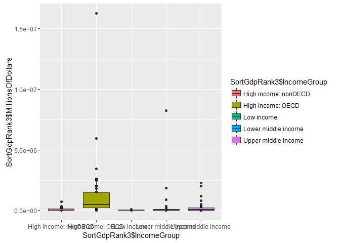

```r
ggplot(SortGdpRank3,  aes(SortGdpRank3$IncomeGroup, SortGdpRank3$MillionsOfDollars, fill=SortGdpRank3$IncomeGroup )) +  geom_point() + geom_boxplot()
```

##### GDP FOR ALL COUNTRIES - Plotted in Grey with Y scale divided by millions

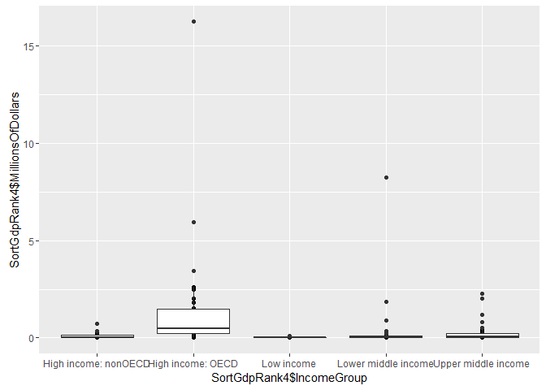

```r
ggplot(SortGdpRank4,  aes(SortGdpRank4$IncomeGroup, SortGdpRank4$MillionsOfDollars )) +  geom_point() + geom_boxplot()
```

##### The USA is such an outlier at 16,244,600 million that the scale is hard to adjust to show the other boxplots’ color or grey.

Data processed without South Sudan information.

##### Question 5 Cut the GDP ranking into 5 separate quantile groups. Make a table versus Income.Group. How many countries are Lower middle income but among the 38 nations with highest GDP?

```r
########5   Cut the GDP ranking into 5 separate quantile groups. Make a table versus Income.Group. How many countries are Lower middle income but among the 38 nations with highest GDP?


QuantGdpRank3 <- SortGdpRank2
QuantGdpRank3$quantile <- ntile(QuantGdpRank3$Ranking, 5)
str(QuantGdpRank3)
```

```
## 'data.frame':    190 obs. of  7 variables:
##  $ EdCountryCode    : chr  "TUV" "KIR" "MHL" "PLW" ...
##  $ IncomeGroup      : chr  "Lower middle income" "Lower middle income" "Lower middle income" "Upper middle income" ...
##  $ ShortName        : chr  "Tuvalu" "Kiribati" "Marshall Islands" "Palau" ...
##  $ Ranking          : int  190 189 188 187 186 185 184 183 182 181 ...
##  $ Economy          : chr  "Tuvalu" "Kiribati" "Marshall Islands" "Palau" ...
##  $ MillionsOfDollars: chr  " 40 " " 175 " " 182 " " 228 " ...
##  $ quantile         : num  5 5 5 5 5 5 5 5 5 5 ...
```

```r
QuantGdpRank3
```

```
##     EdCountryCode          IncomeGroup                      ShortName
## 174           TUV  Lower middle income                         Tuvalu
## 92            KIR  Lower middle income                       Kiribati
## 113           MHL  Lower middle income               Marshall Islands
## 137           PLW  Upper middle income                          Palau
## 156           STP  Lower middle income          São Tomé and Principe
## 59            FSM  Lower middle income                     Micronesia
## 170           TON  Lower middle income                          Tonga
## 46            DMA  Upper middle income                       Dominica
## 39            COM           Low income                        Comoros
## 185           WSM  Lower middle income                          Samoa
## 181           VCT  Upper middle income St. Vincent and the Grenadines
## 69            GRD  Upper middle income                        Grenada
## 93            KNA  Upper middle income            St. Kitts and Nevis
## 184           VUT  Lower middle income                        Vanuatu
```

[output cut: 367 more lines]

```r
table(QuantGdpRank3$quantile,QuantGdpRank3$IncomeGroup)
```

```
##
##     High income: nonOECD High income: OECD Low income Lower middle income
##   1                    4                18          0                   5
##   2                    5                10          1                  13
##   3                    8                 1          9                  12
##   4                    4                 1         16                   8
##   5                    2                 0         11                  16
##
##     Upper middle income
##   1                  11
##   2                   9
##   3                   8
##   4                   8
##   5                   9
```